# Units of Measurement for R Vectors: an Introduction

R has little support for physical measurement units. The exception is formed by time differences: time differences objects of class `difftime` have a `units` attribute that can be modified:

```r
t1 = Sys.time()
t2 = t1 + 3600
d = t2 - t1
class(d)
```

```
## [1] "difftime"
```

```r
units(d)
```

```
## [1] "hours"
```

```r
d
## Time difference of 1 hours
units(d) = "secs"
d
## Time difference of 3600 secs
```

We see here that the `units` method is used to retrieve and modify the unit of time differences.

The `units` package generalizes this idea to other physical units, building upon the udunits2 R package, which in turn is build upon the [udunits2](https://www.unidata.ucar.edu/software/udunits/) C library. The `udunits2` library provides the following operations:

- validating whether an expression, such as `m/s` is a valid physical unit
- verifying whether two units such as `m/s` and `km/h` are convertible
- converting values between two convertible units
- providing names and symbols for specific units
- handle different character encodings (utf8, ascii, iso-8859-1 and latin1)

The `units` R package uses R package [`udunits2`](https://cran.r-project.org/package=udunits2) to extend R with functionality for manipulating numeric vectors that have physical measurement units associated with them, in a similar way as `difftime` objects behave.

## Setting units, unit conversion

Existing units are resolved from a database in the `units` package, called `ud_units`. We can see the first three elements of it by

```r
library(units)
ud_units[1:3]
```

```
## $m
## 1 [m]
##
## $kg
## 1 [kg]
##
## $s
## 1 [s]
```

We can set units to numerical values by `set_units`:

```r
(a <- set_units(runif(10),  m/s))
## Units: [m/s]
##  [1] 0.4518294 0.3910316 0.5732944 0.6965670 0.2450122 0.4020448 0.4025526
##  [8] 0.7891220 0.5043406 0.1370050
```

the result, e.g.

```r
set_units(10, m/s)
## 10 [m/s]
```

literally means "10 times 1 m divided by 1 s". In writing, the "1" values are omitted, and the multiplication is implicit.

The `units` package comes with a list of over 3000 predefined units,

```r
length(ud_units)
```

```
## [1] 3248
```

We can retrieve a single unit from the `ud_units` database by

```r
with(ud_units, km/h)
## 1 [km/h]
```

### Unit conversion

When conversion is meaningful, such as hours to seconds or meters to kilometers, conversion can be done explicitly by setting the units of a vector

```r
b = a
units(b) <- with(ud_units, km/h)
b
## Units: [km/h]
##  [1] 1.6265858 1.4077138 2.0638598 2.5076413 0.8820439 1.4473614 1.4491894
##  [8] 2.8408390 1.8156263 0.4932182
```

## Basic manipulations

### Arithmetic operations

Arithmetic operations verify units, and create new ones

```r
a + a
## Units: [m/s]
##  [1] 0.9036588 0.7820632 1.1465888 1.3931341 0.4900244 0.8040897 0.8051052
##  [8] 1.5782439 1.0086813 0.2740101
a * a
## Units: [m^2/s^2]
##  [1] 0.20414981 0.15290573 0.32866646 0.48520562 0.06003097 0.16164006
##  [7] 0.16204860 0.62271346 0.25435948 0.01877038
a ^ 2
## Units: [m^2/s^2]
##  [1] 0.20414981 0.15290573 0.32866646 0.48520562 0.06003097 0.16164006
##  [7] 0.16204860 0.62271346 0.25435948 0.01877038
a ** -2
## Units: [s^2/m^2]
##  [1]  4.898364  6.539977  3.042598  2.060982 16.658067  6.186585  6.170988
##  [8]  1.605875  3.931444 53.275420
```

and convert to the units of the first argument if necessary:

```r
a + b # m/s + km/h -> m/s
## Units: [m/s]
##  [1] 0.9036588 0.7820632 1.1465888 1.3931341 0.4900244 0.8040897 0.8051052
##  [8] 1.5782439 1.0086813 0.2740101
```

Currently, powers are only supported for integer powers, so using `a ** 2.5` would result in an error.

### Unit simplification

There are some basic simplification of units:

```r
t <- with(ud_units, s)
a * t
## Units: [m]
##  [1] 0.4518294 0.3910316 0.5732944 0.6965670 0.2450122 0.4020448 0.4025526
##  [8] 0.7891220 0.5043406 0.1370050
```

which also work when units need to be converted before they can be simplified:

```r
t <- with(ud_units, min)
a * t
## Units: [m]
##  [1] 27.109764 23.461897 34.397663 41.794022 14.700732 24.122691 24.153157
##  [8] 47.347317 30.260438  8.220303
```

Simplification to unit-less values gives the "1" as unit:

```r
m <- with(ud_units, m)
a * t / m
## Units: [1]
##  [1] 27.109764 23.461897 34.397663 41.794022 14.700732 24.122691 24.153157
##  [8] 47.347317 30.260438  8.220303
```

Allowed operations that require convertible units are `+`, `-`, `==`, `!=`, `<`, `>`, `<=`, `>=`. Operations that lead to new units are `*`, `/`, and the power operations `**` and `^`.

### Mathematical functions

Mathematical operations allowed are: `abs`, `sign`, `floor`, `ceiling`, `trunc`, `round`, `signif`, `log`, `cumsum`, `cummax`, `cummin`.

```r
signif(a ** 2 / 3, 3)
## Units: [m^2/s^2]
##  [1] 0.06800 0.05100 0.11000 0.16200 0.02000 0.05390 0.05400 0.20800 0.08480
## [10] 0.00626
cumsum(a)
## Units: [m/s]
##  [1] 0.4518294 0.8428610 1.4161554 2.1127224 2.3577346 2.7597795 3.1623321
##  [8] 3.9514540 4.4557947 4.5927997
log(a) # base defaults to exp(1)
## Units: [(ln(re 1 m.s-1))]
##  [1] -0.7944506 -0.9389668 -0.5563559 -0.3615913 -1.4064473 -0.9111916
##  [7] -0.9099295 -0.2368344 -0.6845034 -1.9877375
log(a, base = 10)
## Units: [(lg(re 1 m.s-1))]
##  [1] -0.3450255 -0.4077881 -0.2416223 -0.1570371 -0.6108123 -0.3957255
##  [7] -0.3951774 -0.1028559 -0.2972760 -0.8632634
log(a, base = 2)
## Units: [(lb(re 1 m.s-1))]
##  [1] -1.1461499 -1.3546428 -0.8026519 -0.5216659 -2.0290745 -1.3145717
##  [7] -1.3127507 -0.3416798 -0.9875296 -2.8676991
```

### Summary functions

Summary functions `sum`, `min`, `max`, and `range` are allowed:

```r
sum(a)
## 4.5928 [m/s]
min(a)
## 0.137005 [m/s]
max(a)
## 0.789122 [m/s]
range(a)
## Units: [m/s]
## [1] 0.137005 0.789122
with(ud_units, min(m/s, km/h)) # converts to first unit:
## 0.2777778 [m/s]
```

### Printing

Following `difftime`, printing behaves differently for length-one vectors:

```r
a
## Units: [m/s]
##  [1] 0.4518294 0.3910316 0.5732944 0.6965670 0.2450122 0.4020448 0.4025526
##  [8] 0.7891220 0.5043406 0.1370050
a[1]
## 0.4518294 [m/s]
```

### Subsetting

The usual subsetting rules work:

```r
a[2:5]
## Units: [m/s]
## [1] 0.3910316 0.5732944 0.6965670 0.2450122
a[-(1:9)]
## 0.137005 [m/s]
```

### Concatenation

```r
c(a,a)
## Units: [m/s]
##  [1] 0.4518294 0.3910316 0.5732944 0.6965670 0.2450122 0.4020448 0.4025526
##  [8] 0.7891220 0.5043406 0.1370050 0.4518294 0.3910316 0.5732944 0.6965670
## [15] 0.2450122 0.4020448 0.4025526 0.7891220 0.5043406 0.1370050
```

concatenation converts to the units of the first argument, if necessary:

```r
c(a,b) # m/s, km/h -> m/s
## Units: [m/s]
##  [1] 0.4518294 0.3910316 0.5732944 0.6965670 0.2450122 0.4020448 0.4025526
##  [8] 0.7891220 0.5043406 0.1370050 0.4518294 0.3910316 0.5732944 0.6965670
## [15] 0.2450122 0.4020448 0.4025526 0.7891220 0.5043406 0.1370050
c(b,a) # km/h, m/s -> km/h
## Units: [km/h]
##  [1] 1.6265858 1.4077138 2.0638598 2.5076413 0.8820439 1.4473614 1.4491894
##  [8] 2.8408390 1.8156263 0.4932182 1.6265858 1.4077138 2.0638598 2.5076413
## [15] 0.8820439 1.4473614 1.4491894 2.8408390 1.8156263 0.4932182
```

## Conversion to/from `difftime`

From `difftime` to `units`:

```r
t1 = Sys.time()
t2 = t1 + 3600
d = t2 - t1
(du = as_units(d))
## 1 [h]
```

vice versa:

```r
(dt = as_difftime(du))
## Time difference of 1 hours
class(dt)
```

```
## [1] "difftime"
```

## units in `matrix` objects

```r
set_units(matrix(1:4,2,2), m/s)
## Units: [m/s]
##      [,1] [,2]
## [1,]    1    3
## [2,]    2    4
set_units(matrix(1:4,2,2), m/s * m/s)
## Units: [m^2/s^2]
##      [,1] [,2]
## [1,]    1    3
## [2,]    2    4
```

but

```r
set_units(matrix(1:4,2,2), m/s) %*% set_units(4:3, m/s)
```

```
##      [,1]
## [1,]   13
## [2,]   20
```

strips units.

## units objects in `data.frame`s

units in `data.frame` objects are printed, but do not appear in `summary`:.

```r
set.seed(131)
d <- data.frame(x = runif(4),
                    y = set_units(runif(4), s),
                    z = set_units(1:4, m/s))
d
```

```
##           x             y       z
## 1 0.2064370 0.8463468 [s] 1 [m/s]
## 2 0.1249422 0.5292048 [s] 2 [m/s]
## 3 0.2932732 0.5186254 [s] 3 [m/s]
## 4 0.3757797 0.2378545 [s] 4 [m/s]
```

```r
summary(d)
```

```
##        x                y                z
##  Min.   :0.1249   Min.   :0.2379   Min.   :1.00
##  1st Qu.:0.1861   1st Qu.:0.4484   1st Qu.:1.75
##  Median :0.2499   Median :0.5239   Median :2.50
##  Mean   :0.2501   Mean   :0.5330   Mean   :2.50
##  3rd Qu.:0.3139   3rd Qu.:0.6085   3rd Qu.:3.25
##  Max.   :0.3758   Max.   :0.8463   Max.   :4.00
```

```r
d$yz = with(d, y * z)
d
```

```
##           x             y       z            yz
## 1 0.2064370 0.8463468 [s] 1 [m/s] 0.8463468 [m]
## 2 0.1249422 0.5292048 [s] 2 [m/s] 1.0584095 [m]
## 3 0.2932732 0.5186254 [s] 3 [m/s] 1.5558761 [m]
## 4 0.3757797 0.2378545 [s] 4 [m/s] 0.9514180 [m]
```

```r
d[1, "yz"]
## 0.8463468 [m]
```

## formatting

Units are often written in the form `m2 s-1`, for square meter per second. This can be defined as unit, and also parsed by `as_units`:

```r
(x = 1:10 * as_units("m2 s-1"))
## Units: [m^2/s]
##  [1]  1  2  3  4  5  6  7  8  9 10
```

udunits understands such string, and can convert them

```r
y = 1:10 * with(ud_units, m^2/s)
x + y
## Units: [m^2/s]
##  [1]  2  4  6  8 10 12 14 16 18 20
```

Printing units in this form is done by

```r
deparse_unit(x)
```

```
## [1] "m2 s-1"
```

## plotting

Base scatter plots and histograms support automatic unit placement in axis labels. In the following example we first convert to SI units. (Unit `in` needs a bit special treatment, because `in` is a reserved word in R.)

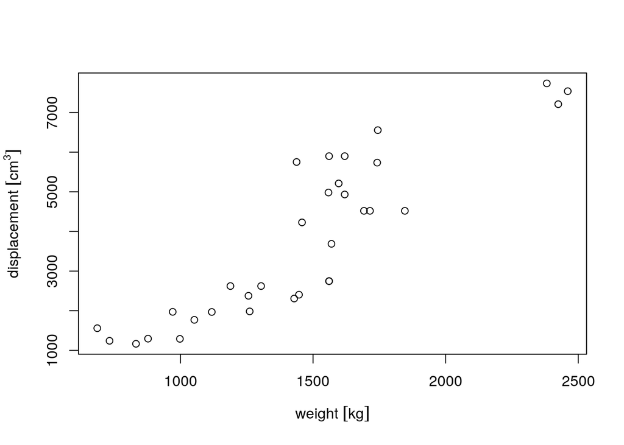

```r
mar = par("mar") + c(0, .3, 0, 0)
displacement = mtcars$disp * ud_units[["in"]]^3
units(displacement) = with(ud_units, cm^3)
weight = mtcars$wt * 1000 * with(ud_units, lb)
units(weight) = with(ud_units, kg)
par(mar = mar)
plot(weight, displacement)
```

We can change grouping symbols from `[ ]` into `( )`:

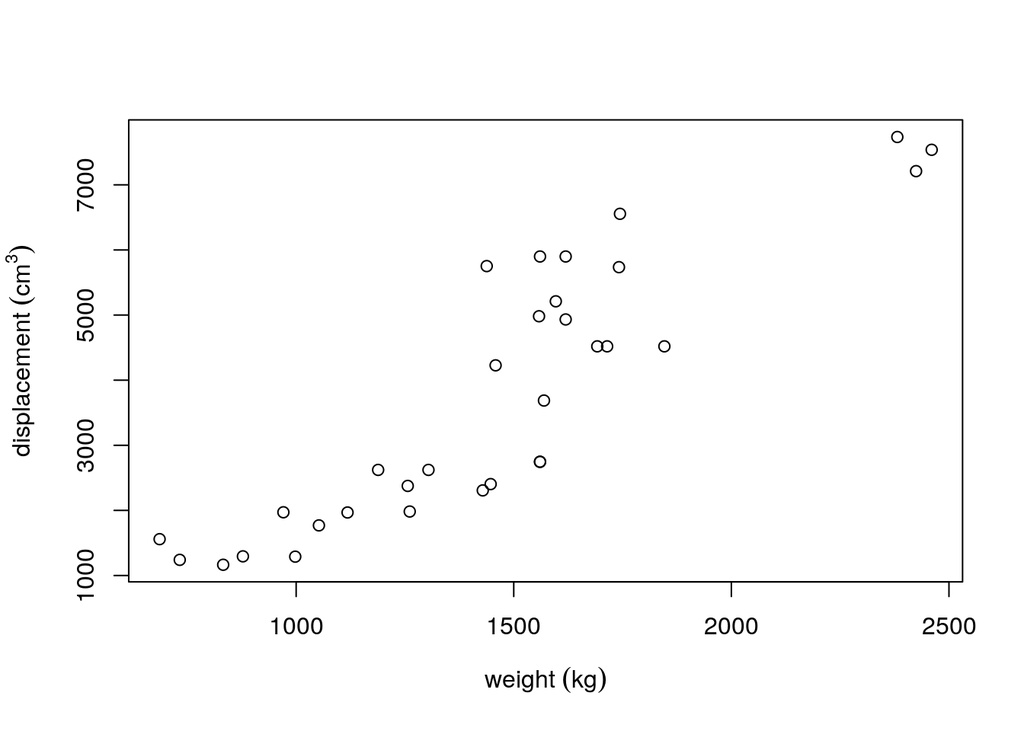

```r
units_options(group = c("(", ")") )  # parenthesis instead of square brackets
par(mar = mar)
plot(weight, displacement)
```

We can also remove grouping symbols, increase space between variable name and unit by:

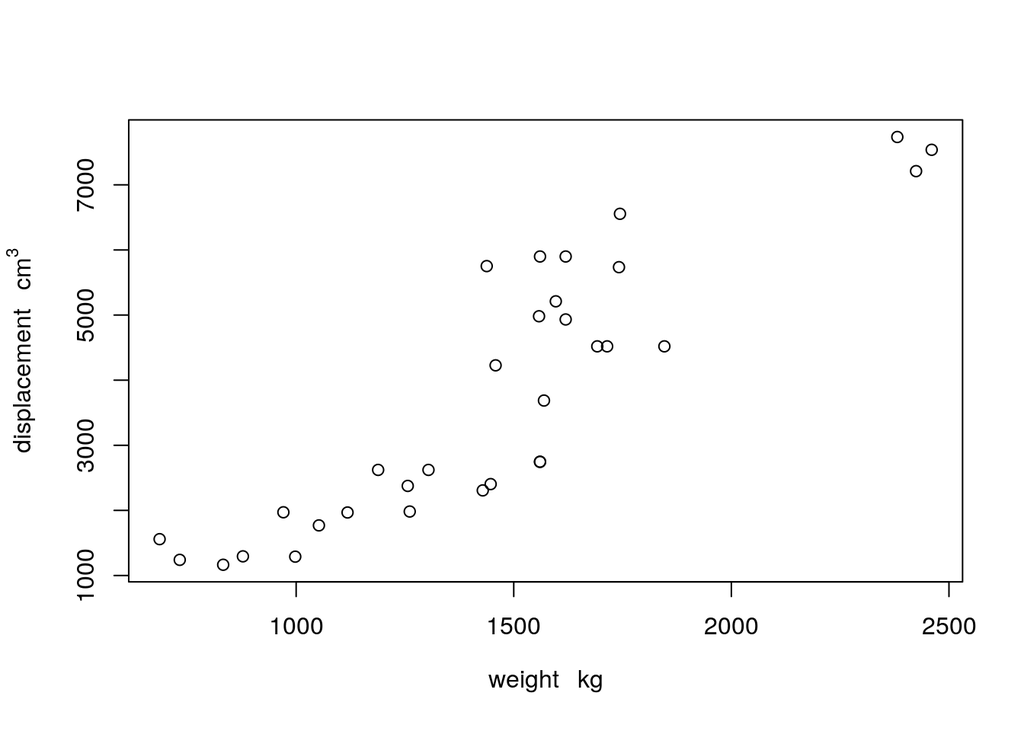

```r
units_options(sep = c("~~~", "~"), group = c("", ""))  # no brackets; extra space
par(mar = mar)
plot(weight, displacement)
```

More complex units can be plotted either with negative powers, or as divisions, by modifying one of `units`'s global options using `units_options`:

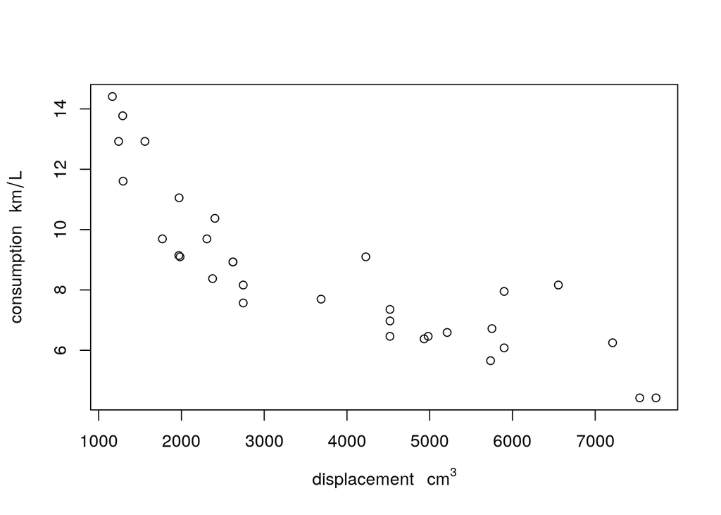

```r
gallon = as_units("gallon")
consumption = mtcars$mpg * with(ud_units, mi/gallon)
units(consumption) = with(ud_units, km/l)
par(mar = mar)
plot(displacement, consumption) # division in consumption
```

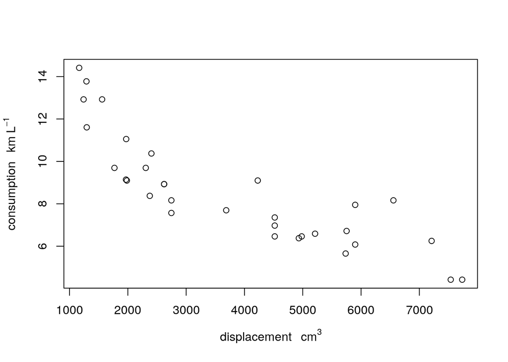

```r
units_options(negative_power = TRUE) # division becomes ^-1
plot(displacement, consumption) # division in consumption
```

As usual, units modify automatically in expressions:

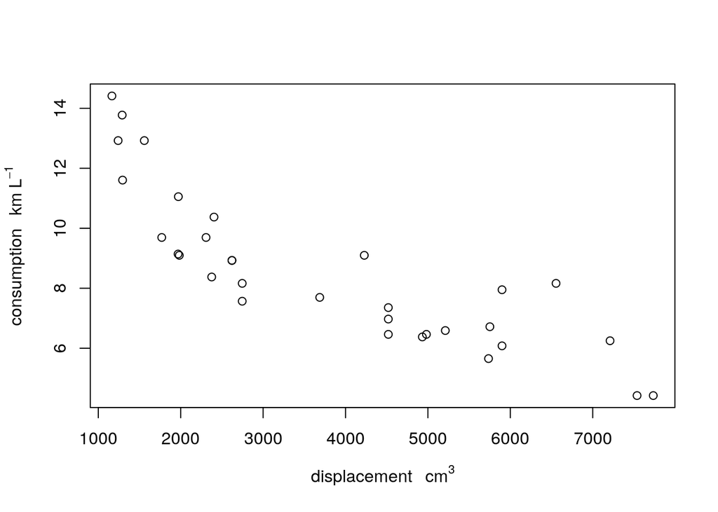

```r
units_options(negative_power = TRUE) # division becomes ^-1
par(mar = mar)
plot(displacement, consumption)
```

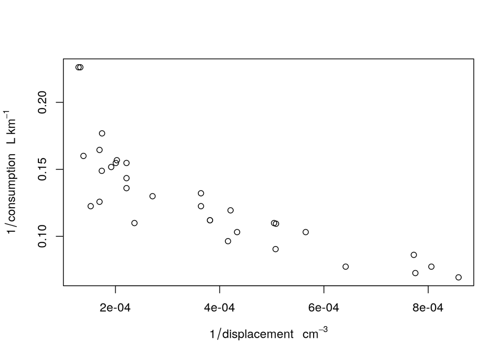

```r
plot(1/displacement, 1/consumption)
```